# Google restaurant reviews in Kuala Lumpur, Petaling Jaya and Shah Alam, Malaysia

Part one

Author

Sean Ng

Modified

December 12, 2025

## Introduction and overview

A common refrain for this postmodern age is that online reviews are useless.

Today, we’re looking at two different sets of scraped data to see to what extent that is true. Restaurant reviews from Google and Trip Advisor in Malaysia were scraped by [Ng Choon Khon](https://www.kaggle.com/datasets/choonkhonng/malaysia-restaurant-review-datasets) using the Selenium library.

Whilst this impacts and limits the dataset, we should still make the best use of it we can: Google’s official API only allows five reviews to be extracted per restaurant because data freely given to the world must be paywalled and sold back to you.

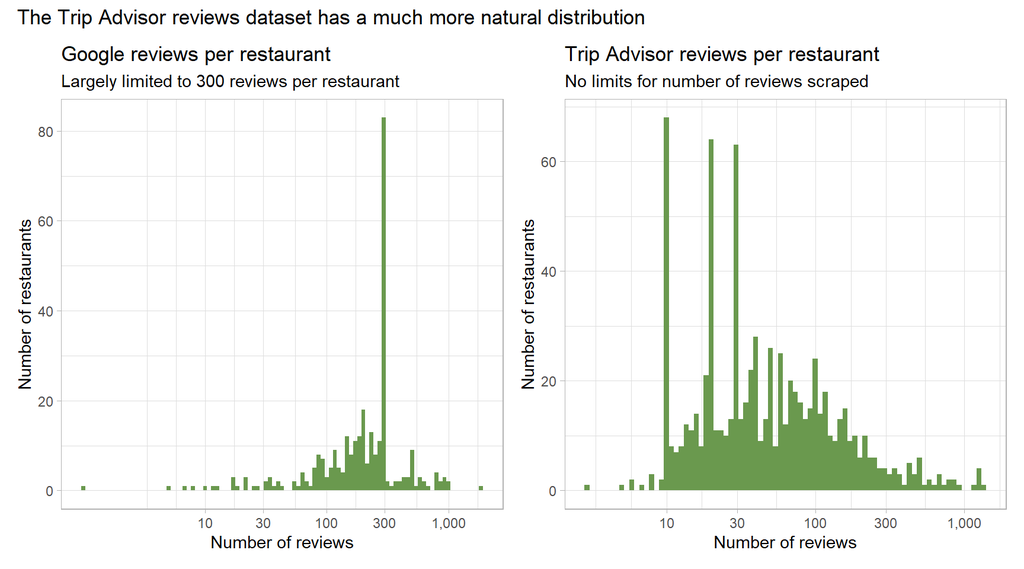

Google reviews are sorted by default by “relevance”, so it is only possible to say that this was determined by a combination of recency, quality (word count, images) and whether or not a review was regarded by the community as helpful.

Let’s review the limitations once more, before we look into these datasets:

- Google’s dataset is not a representative sample of reviews, as many restaurants only have the first 300 most “relevant” reviews. Google reviews, in general, are less policed, with numerous instances of scams and fake reviews.
- Both Google maps and Trip Advisor are principally English language platforms when it isn’t spoken by the majority of the population. Upon a cursory inspection, there are very few reviews in Malay or with Malay words in Google (0.28%) and even less in Trip Advisor (0.14%). This is extremely different from even urban demographics where there are proportionally more minorities, though this skew is more understandable on Trip Advisor than on Google.
- The price range is missing from this data. This is unfortunate because price is one of the main topics mentioned in reviews.
- These reviews were extracted three years ago: some of these restaurants have closed. Before we re-scrape the data and update these datasets, let’s see what is of most in the existing data (which was used to make a sentiment analysis app).

The purpose of this series of analyses is to better understand Google and Trip Advisor’s rating systems in order to better interpret reviews and choose better restaurants.

Because whilst reviews themselves were meant to be informational, expressive or cautionary, the platforms are mired in layers of obfuscation, gamification and marketing; additionally, all reviews are affected by prevailing social mores (we will discuss below the skew towards five stars). This leads me to question that despite all the data we have, how much about restaurant reviews will be actually quantifiable.

## Adding cuisine

These are the columns present in the Google dataset:

```
[1] "author"     "rating"     "review"     "restaurant" "location"
```

Trip Advisor has additional columns for `review title` and `date`.

Let’s add a column for cuisine (the code can be downloaded at the top of the page, but it was a lot of manual work) to increase interpretability and to maximise the usefulness of the data. We’ll narrow down the scope to locations in the Klang Valley (KL, PJ and Shah Alam, in the datasets; since I’m most familiar with and most interested in this metro).

Determining the cuisine of a restaurant was mostly fairly obvious, and the categories hopefully self-explanatory. Additional notes on the coding of these cuisines may be found in the appendices.

Let’s start first with an overview of both datasets, now with cuisines included. From the plot below, we see that:

- South Asian, Chinese, Casual Western, Japanese and Bars are the most commonly-reviewed restaurants in the Klang Valley. These are not the most commonly-visited restaurants.
- Chinese, Casual Western, Malaysian and Thai are the lowest-rated cuisines.
- Fusion, Other Upmarket (experiential dining or unspecified “international” cuisine) and bars have the highest ratings, with 60% or more of all reviews being five stars.
- Trip Advisor and Google reviewers differ the most on their opinions of Levantine, Casual Western and Japanese restaurants.
- The x-axes on the plots below show the percentage of reviews that are five stars by cuisine. This actually provides much more differentiation than just the mean rating, as we will discuss in the next section.

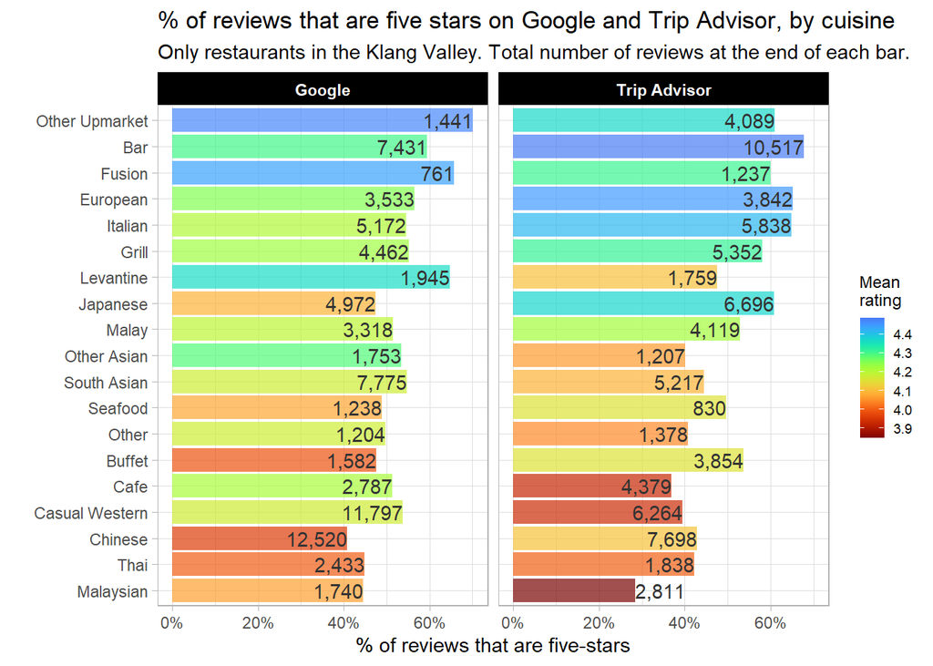

## Comparisons of average ratings

With reference to the histograms below, that ratings are skewed towards the higher end: the mean rating of restaurants on Google is **4.16** and the mean rating on Trip Advisor is **4.22**. The median and mode for both datasets is **5**.

It really could be said that the default review rating is five stars. This means that restaurant reviews on these platforms are very lax. It is hard for me to believe that half of all reviews were about a truly exceptional dining experience: **51.87%** of all ratings in the Google dataset for the Klang Valley are five stars; in Trip Advisor, it was **52.79%**.

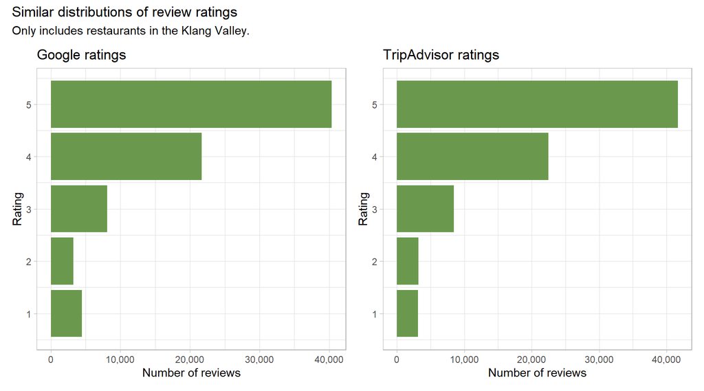

Given that reviews are limited to a one-to-five scale, there is not very much differentiation amongst how restaurants are rated. In the scatterplots below, we note restaurants that almost all restaurants mostly receive five stars (blue) or four stars (green). This means that neither Google nor Trip Advisor ratings are particularly useful at distinguishing between restaurants.

The number of total reviews is correlated with mean rating.

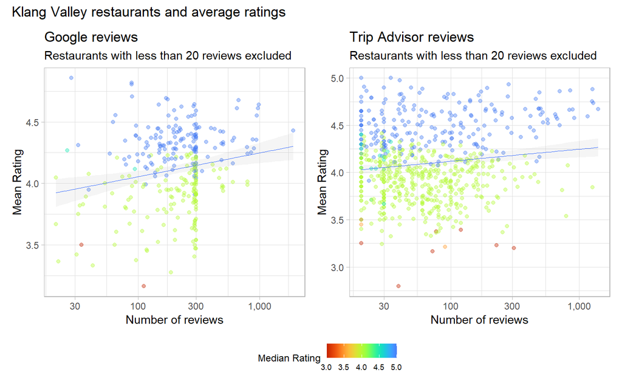

Are reviews useful? The commonality of five-star reviews indicate that the mean rating is more likely an indicator of expectations being met rather than any true excellence.

These differences probably come down to the reviewers on Google and Trip Advisor and their respective purposes. Google reviewers are often locals or general consumers, whilst Trip Advisor reviewers tend to be travellers who have to provide more structured, specific reviews, leading to less casual reviews as there is a minimum word count required.

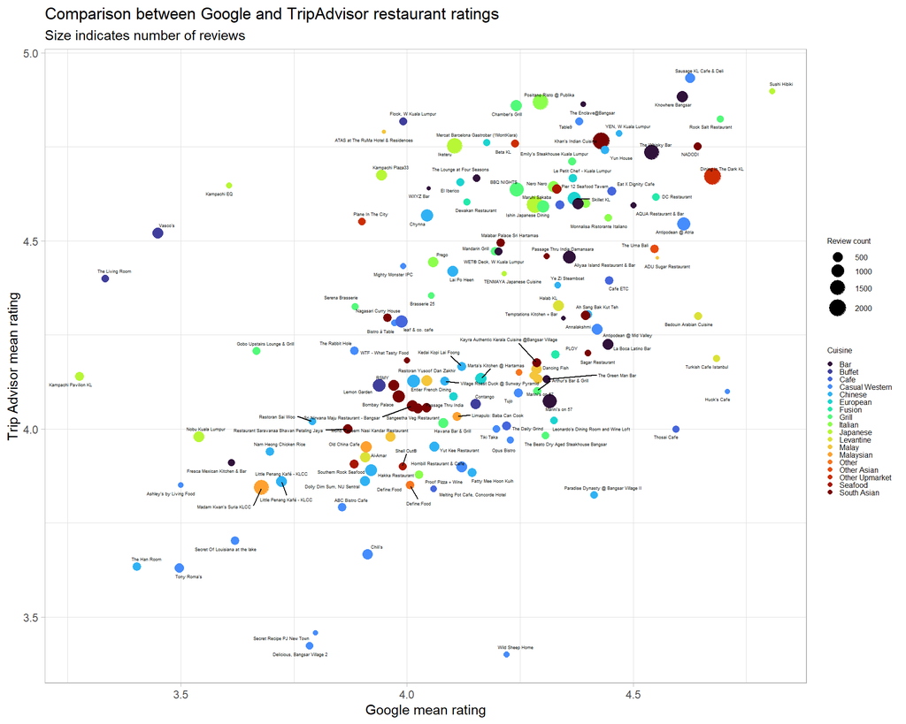

It’s possible that reviews are useless.

Good service and environment can prevent a one-star review. Humans are crazy and feel debts viscerally. Separate food from service and waiters? But restaurants don’t do that. Dining is an experience, and all aspects of the experience are vital.

This is one of those subjects where we all have experience. And that experience is applicable.

For me, I see that the more localised, longstanding levantine (Bedouin and Istanbul) restaurants are much more popular on Google (with locals), rather than on Trip Advisor with many more expats and travellers.

## Conclusions: Part one

Let’s review what we’ve learnt from the datasets:

In spite of all this, I still haven’t learnt anything that I instinctually did not know. In my day-to-day life, when engaging with online reviews, I’m still forced to engage with reviews individually, apart from the summary chart

Outside of the home, hawker centres and coffee shops are places where food is most commonly consumed. Yet these businesses are not reviewed with anywhere the same frequency as the casual western eateries or chinese restaurants/*dai chows*. Food we consume every day is not subject to the same expectations as fine dining. But even more casual dining options warrant reviews.

Or, the system could be skewed against hawkers. It is difficult to mark individual hawkers since they operate from within the premises of another business. Additionally, hawkers are much less likely to engage with Google or Trip Advisor to curate or market their online presence, leading to these platforms being blind to the needs of hawkers and continue to cater towards restaurants. Restaurants do spend on marketing (i.e. paying for visibility on Google Maps)

```
# A tibble: 53 × 2
   restaurant                                         n
   <chr>                                          <int>
 1 Din Tai Fung 鼎泰豐 at The Gardens Mall          792
 2 Old Shanghai                                     599
 3 Lai Po Heen                                      336
 4 Ah Sang Bak Kut Teh                              300
 5 Boon Signature Roast Pork                        300
 6 Din Tai Fung 鼎泰豐 at 1 Utama Shopping Centre   300
 7 Dolly Dim Sum, NU Sentral                        300
 8 Fatty Mee Hoon Kuih                              300
 9 Hakka Restaurant                                 300
10 Nam Heong Vintage, Pavilion Elite                300
# ℹ 43 more rows
```